# DS202_lab3

Saketh Jonnadula

3/5/2021

Setup and cleaning up the data

```r
dat <- readxl::read_xls('/Users/Saketh3/desktop/DS202/DS202_lab3/GSS.xls')
library(dplyr)
```

```r
library(ggplot2)
library(tidyverse)
dat <- dat %>% rename(year = `Gss year for this respondent`, id = `Respondent id number`, hours = `Number of hours usually work a week`, marital = `Marital status`, school = `Highest year of school completed`, sex = `Respondents sex`, party = `Political party affiliation`, happiness = `General happiness`, ballotUsed = `Ballot used for interview`)
```

Question #1

```r
newdf <- as.data.frame(dat)
newdf <- filter(newdf, school != 'No answer' & school != "Don't know" & !is.na(school) & school != "NA" )
unique(newdf$school)
```

```
##  [1] "16" "10" "12" "17" "14" "13" "6"  "9"  "8"  "11" "7"  "15" "20" "18" "3"
## [16] "2"  "4"  "5"  "19" "1"  "0"
```

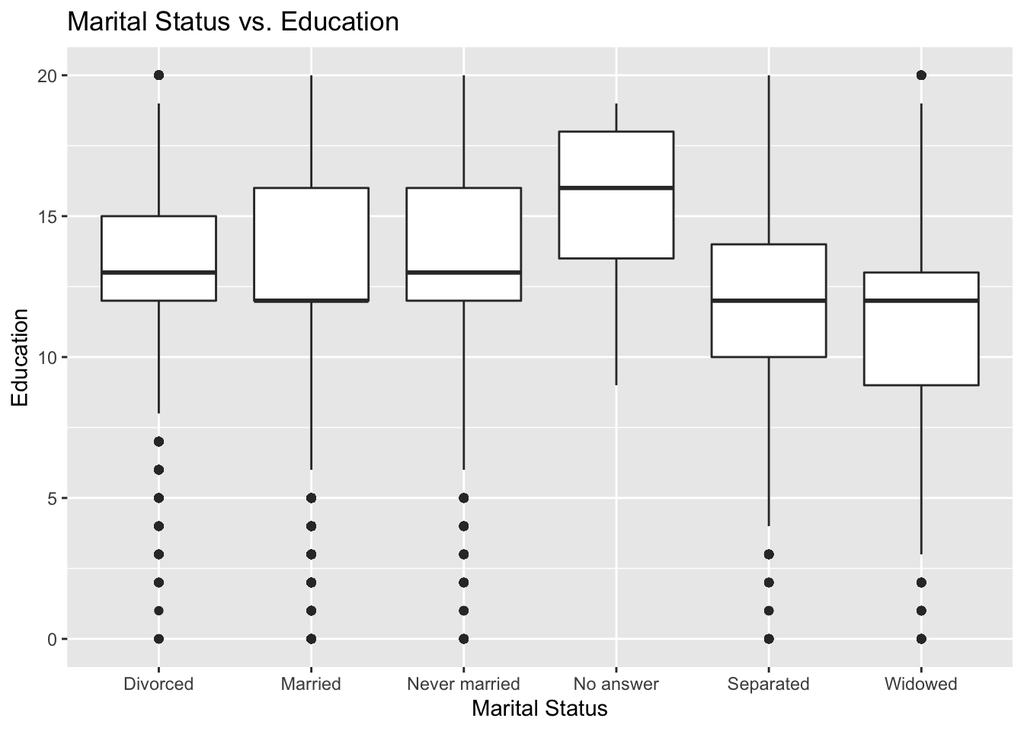

```r
newdf$school <- as.numeric(newdf$school)
ggplot(newdf, aes(y=school, x=marital), fill=school) + geom_boxplot()+xlab("Marital Status")+ylab("Education")+ggtitle("Marital Status vs. Education")
```

You can see that the ones with no answer seem to have the highest mean education,which I didnt expect or account for. You also can see the rest have around the same mean seems to be in the range of 11-13.

Question #2

```r
df <- as.data.frame(dat)
df <- filter(df, school != "Don't know" & school != 'No answer' & school != "NA" & !is.na(school))
df$school <- as.numeric(df$school)

df %>% group_by(marital) %>% summarize(meanRate = mean(school, na.rm=TRUE), sdRate = sd(school, na.rm=TRUE), numRows = n())
```

```
## # A tibble: 6 x 4
##   marital       meanRate sdRate numRows
## * <chr>            <dbl>  <dbl>   <int>
## 1 Divorced          13.1   2.91    8363
## 2 Married           13.0   3.19   34053
## 3 Never married     13.4   2.85   13801
## 4 No answer         15.5   2.84      23
## 5 Separated         11.9   3.28    2233
## 6 Widowed           11.2   3.49    6164
```

Question #3

```r
df2 <- as.data.frame(dat)
str(df2)
```

```
## 'data.frame':    64816 obs. of  9 variables:
##  $ year      : num  1972 1972 1972 1972 1972 ...
##  $ id        : num  1 2 3 4 5 6 7 8 9 10 ...
##  $ hours     : chr  "Not applicable" "Not applicable" "Not applicable" "Not applicable" ...
##  $ marital   : chr  "Never married" "Married" "Married" "Married" ...
##  $ school    : chr  "16" "10" "12" "17" ...
##  $ sex       : chr  "Female" "Male" "Female" "Female" ...
##  $ party     : chr  "Ind,near dem" "Not str democrat" "Independent" "Not str democrat" ...
##  $ happiness : chr  "Not too happy" "Not too happy" "Pretty happy" "Not too happy" ...
##  $ ballotUsed: chr  "Not applicable" "Not applicable" "Not applicable" "Not applicable" ...
```

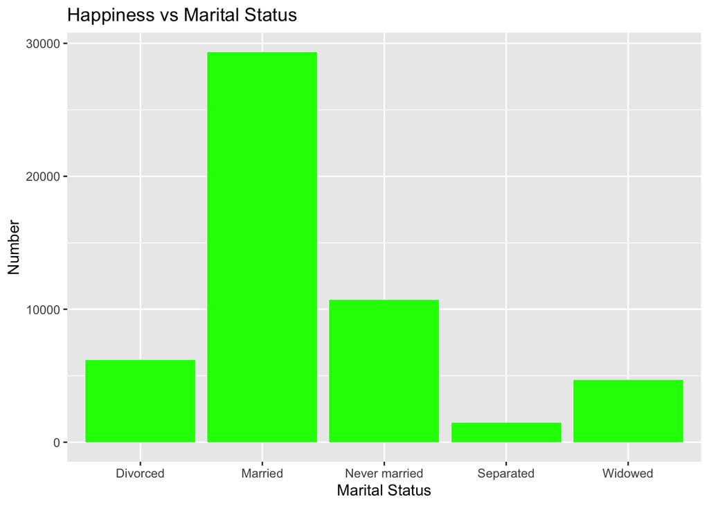

```r
dfHappy <- df2 %>% group_by(marital) %>% filter(happiness=="Pretty happy" | happiness=="Very happy") %>% filter(marital!="No answer")
dfNotHappy <- df2 %>% group_by(marital) %>% filter(happiness=="Not too happy") %>% filter(marital!="No answer")

notHappy <- dfNotHappy %>% group_by(marital) %>% summarize(toalUnhappy = n())
#notHappy

happy <- dfHappy %>% group_by(marital) %>% summarize(totalHappy = n())
#happy

ggplot(dfHappy, aes(x=marital)) + geom_bar(fill="green") + ggtitle("Happiness vs Marital Status")+xlab("Marital Status")+ylab("Number")
```

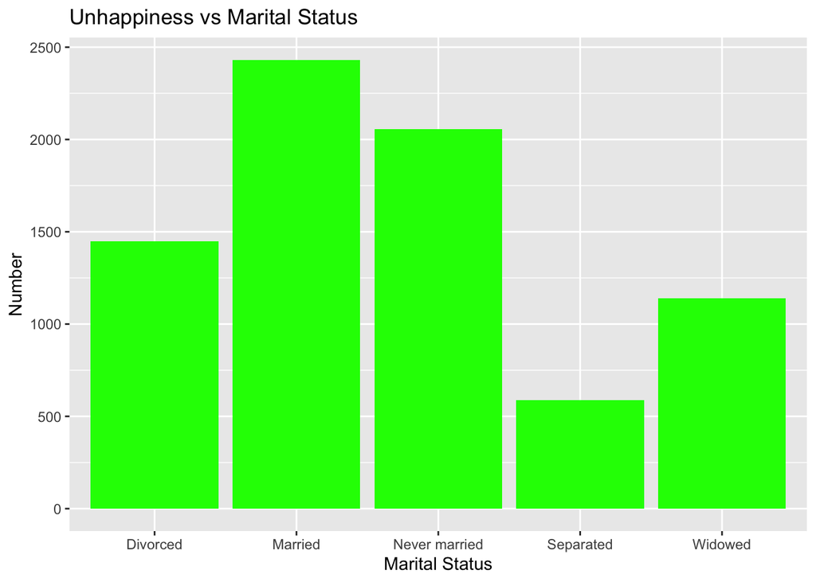

```r
ggplot(dfNotHappy, aes(x=marital)) + geom_bar(fill="green")  + ggtitle("Unhappiness vs Marital Status")+xlab("Marital Status")+ylab("Number")
```

It would seem that there are more people married and happy than there are of any other group.There are about 30,000 happy people that are married and around 2500 people that are unhappy and married so I would say that people are generally happier while married. It also seems that never married people are happier than the other groups of people expect the married people.

Question #4

```r
unique(dfHappy$party)
```

```
##  [1] "Independent"        "Strong democrat"    "Ind,near dem"
##  [4] "Not str republican" "Ind,near rep"       "Not str democrat"
##  [7] "Strong republican"  "Other party"        "No answer"
## [10] "Don't know"
```

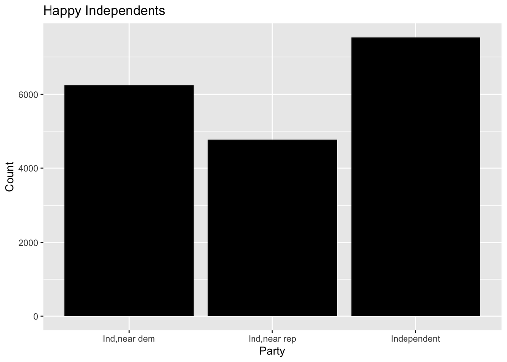

```r
dfHappy2<- dfHappy %>% group_by(marital) %>% filter(party=="Independent" | party=="Ind,near rep" | party=="Ind,near dem")
#dfHappy2

indy1 <- dfHappy2 %>% summarize(totalHappyI = n())
#indy1
ggplot(dfHappy2, aes(x=party)) + geom_bar(fill="black") + ggtitle("Happy Independents")+xlab("Party")+ylab("Count")
```

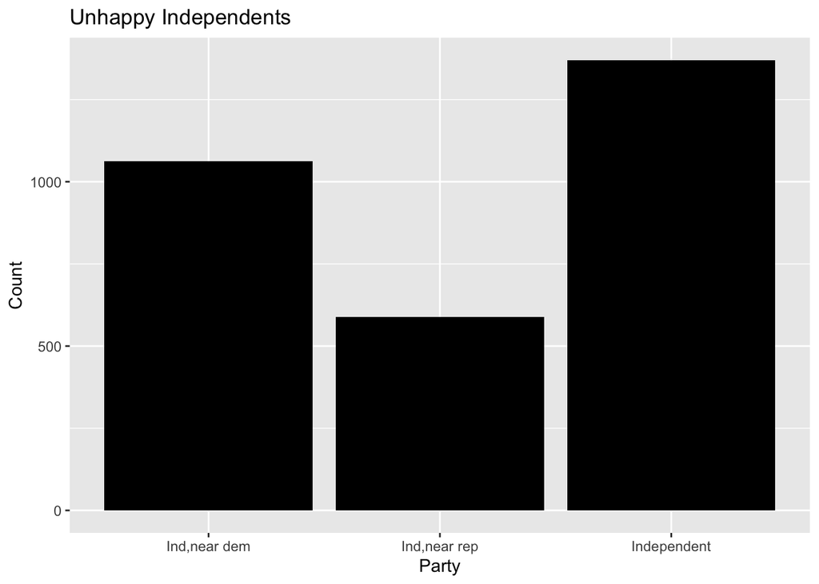

```r
dfNotHappy2 <- dfNotHappy %>% group_by(marital) %>% filter(party=="Independent" | party=="Ind,near rep" | party=="Ind,near dem")
#dfNotHappy2

indy2 <- dfNotHappy2 %>% summarize(totalNotHappyI = n())
#indy2
ggplot(dfNotHappy2, aes(x=party)) + geom_bar(fill="black") + ggtitle("Unhappy Independents")+xlab("Party")+ylab("Count")
```

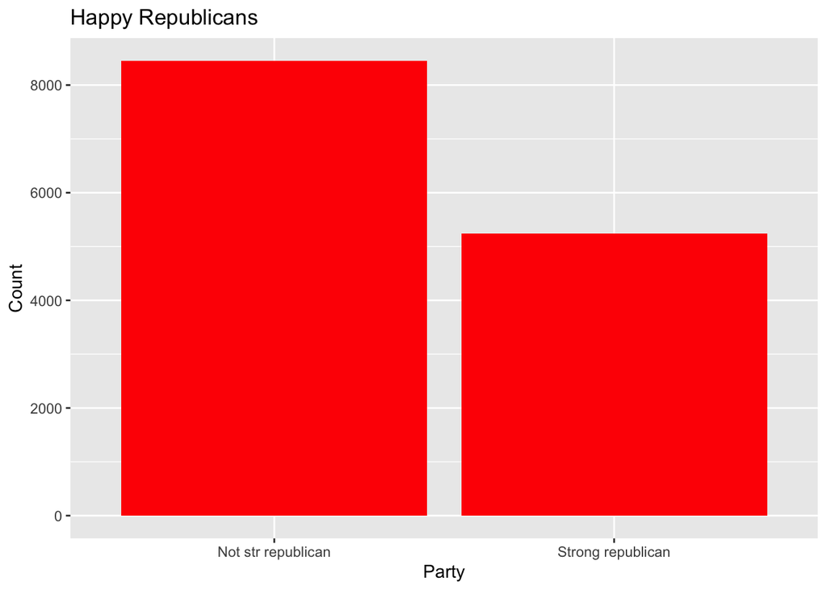

```r
dfHappy3 <- dfHappy %>% group_by(marital) %>% filter(party=="Strong republican" | party=="Not str republican")
rep1 <- dfHappy3 %>% summarize(totalHappyR = n())
#rep1
ggplot(dfHappy3, aes(x=party)) + geom_bar(fill="red") + ggtitle("Happy Republicans")+xlab("Party")+ylab("Count")
```

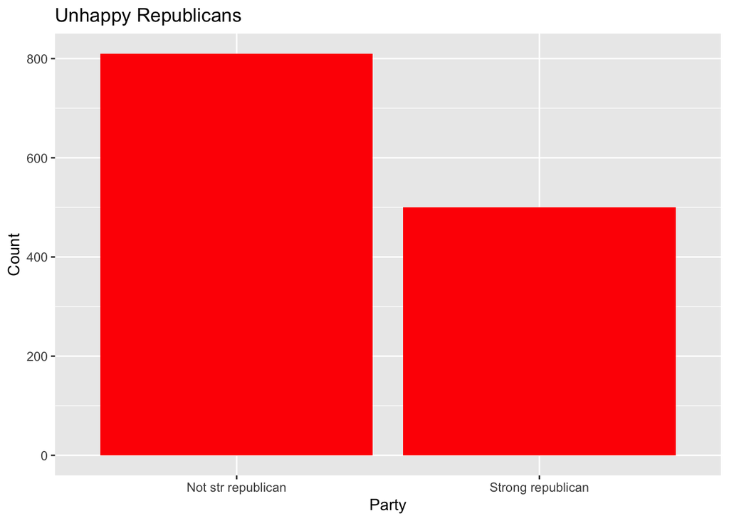

```r
dfNotHappy3 <- dfNotHappy %>% group_by(marital) %>% filter(party=="Strong republican" | party=="Not str republican")
rep2 <- dfNotHappy3 %>% summarize(totalNotHappyR = n())
#rep2
ggplot(dfNotHappy3, aes(x=party)) + geom_bar(fill="red") + ggtitle("Unhappy Republicans")+xlab("Party")+ylab("Count")
```

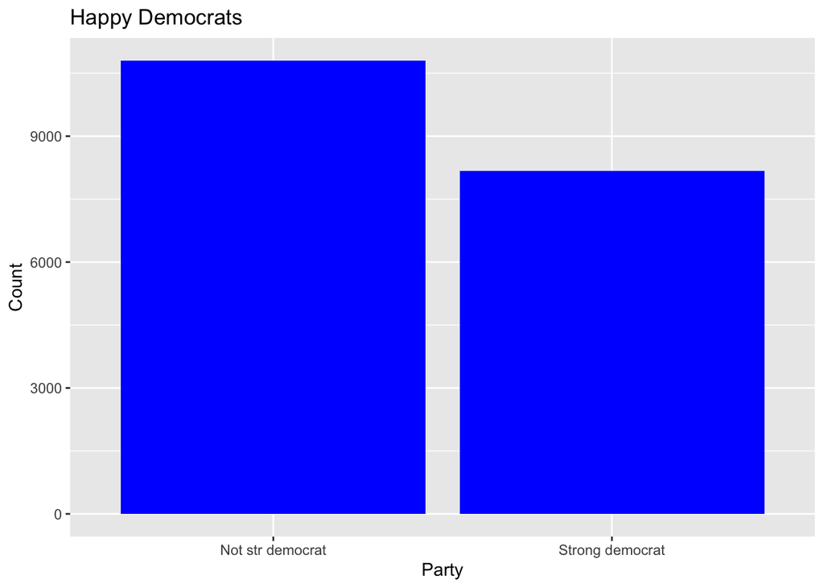

```r
dfHappy4 <- dfHappy %>% group_by(marital) %>% filter(party=="Strong democrat" | party=="Not str democrat")
dem1 <- dfHappy4 %>% summarize(totalHappyR = n())
#dem1
ggplot(dfHappy4, aes(x=party)) + geom_bar(fill="blue") + ggtitle("Happy Democrats")+xlab("Party")+ylab("Count")
```

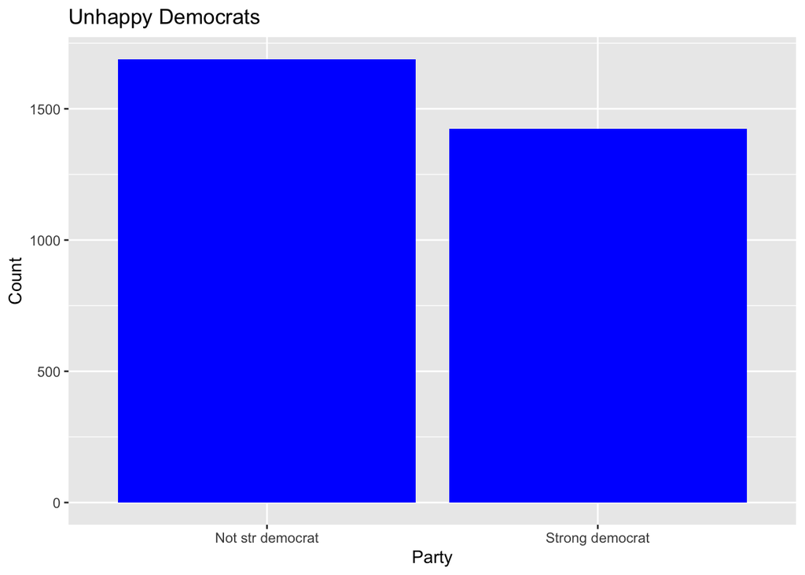

```r
dfNotHappy4 <- dfNotHappy %>% group_by(marital) %>% filter(party=="Strong democrat" | party=="Not str democrat")
dem2 <- dfNotHappy4 %>% summarize(totalNotHappyR = n())
#dem2
ggplot(dfNotHappy4, aes(x=party)) + geom_bar(fill="blue") + ggtitle("Unhappy Democrats")+xlab("Party")+ylab("Count")
```

Question #5

```r
df5 <- as.data.frame(dat)
df5 <- filter(df5, !is.na(school) & school != 'No answer' & school != "Don't know" & school != "NA" )
unique(df5$school)
```

```
##  [1] "16" "10" "12" "17" "14" "13" "6"  "9"  "8"  "11" "7"  "15" "20" "18" "3"
## [16] "2"  "4"  "5"  "19" "1"  "0"
```

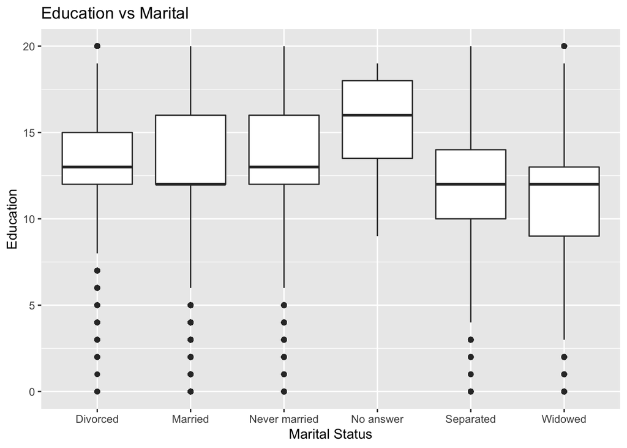

```r
df5$school <- as.numeric(df5$school)

ggplot(data = df5, aes(x = marital, y = school)) + geom_boxplot() + ggtitle("Education vs Marital") + xlab("Marital Status") + ylab("Education")
```

Question #6 Happiness vs hours worked

```r
df6 <- select(dat, hours, happiness)
df6$hours <- as.numeric(df6$hours)
```

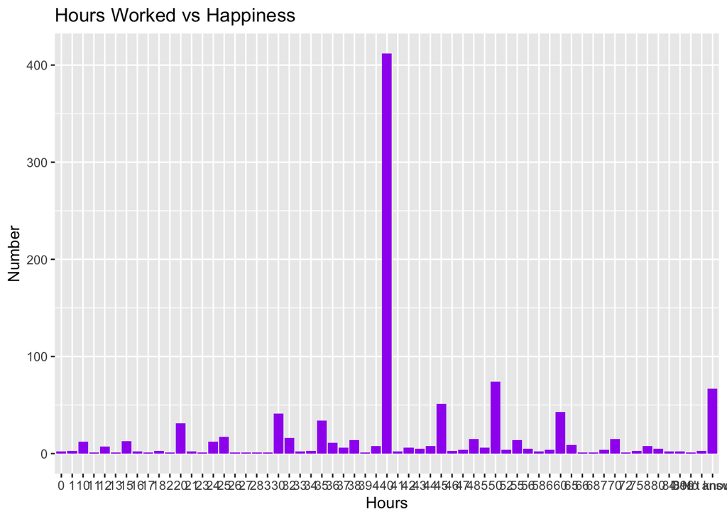

```r
dfHappy <- df2 %>% group_by(hours) %>% filter(happiness=="Pretty happy" | happiness=="Very happy") %>% filter(hours!="Not applicable")
dfNotHappy <- df2 %>% group_by(hours) %>% filter(happiness=="Not too happy") %>% filter(hours !="Not applicable")

notHappy <- dfNotHappy %>% group_by(hours) %>% summarize(totalUnhappy = n())

happy <- dfHappy %>% group_by(hours) %>% summarize(totalHappy = n())

ggplot(dfHappy, aes(x= hours)) + geom_bar(fill="purple") + ggtitle("Hours Worked vs Happiness")+xlab("Hours")+ylab("Number")
```

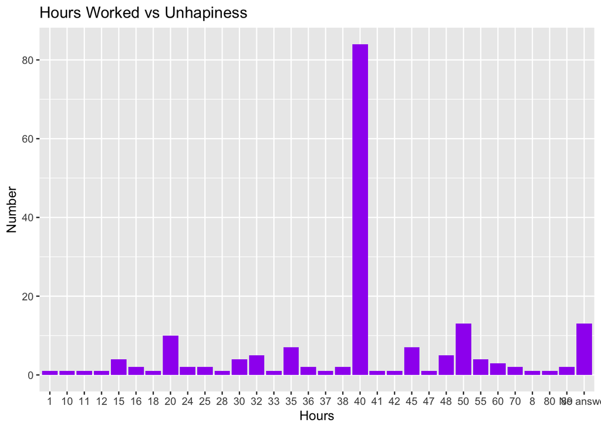

```r
ggplot(dfNotHappy, aes(x=hours)) + geom_bar(fill="purple")  + ggtitle("Hours Worked vs Unhapiness")+xlab("Hours")+ylab("Number")
```

You can see that more people are relativity happy with the amount of hours they work. So you can see that there is some corrilation to happiness and hours worked because some people enjoy working long work weeks and some people enjoy having short hour weeks.

Question #6 Happiness vs education

```r
df6 <- select(dat, school, happiness)
df6$school <- as.numeric(df6$school)
```

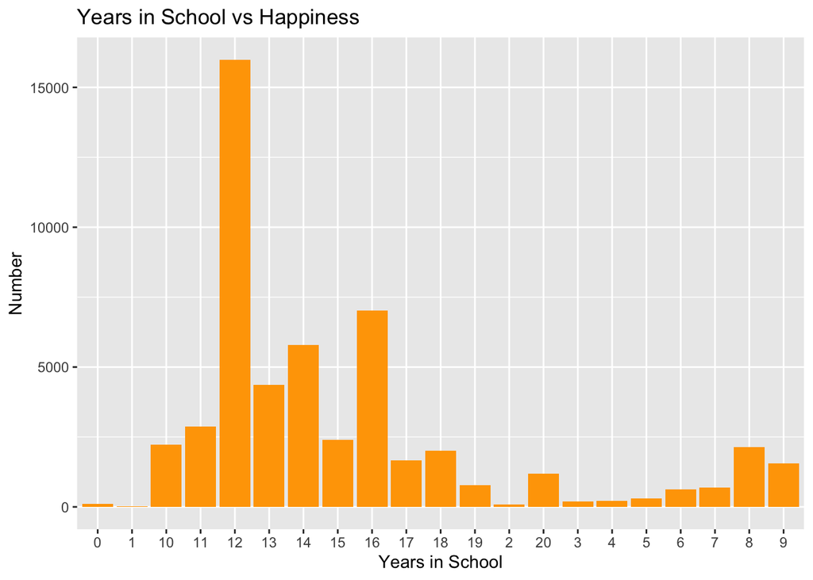

```r
dfHappy <- df2 %>% group_by(school) %>% filter(happiness=="Pretty happy" | happiness=="Very happy") %>% filter(school != 'No answer' & school != "Don't know" & school != "NA" )

dfNotHappy <- df2 %>% group_by(school) %>% filter(happiness=="Not too happy") %>% filter(school != 'No answer' & school != "Don't know" & school != "NA" )

notHappy <- dfNotHappy %>% group_by(school) %>% summarize(totalUnhappy = n())

happy <- dfHappy %>% group_by(school) %>% summarize(totalHappy = n())

ggplot(dfHappy, aes(x= school)) + geom_bar(fill="orange") + ggtitle("Years in School vs Happiness")+xlab("Years in School")+ylab("Number")
```

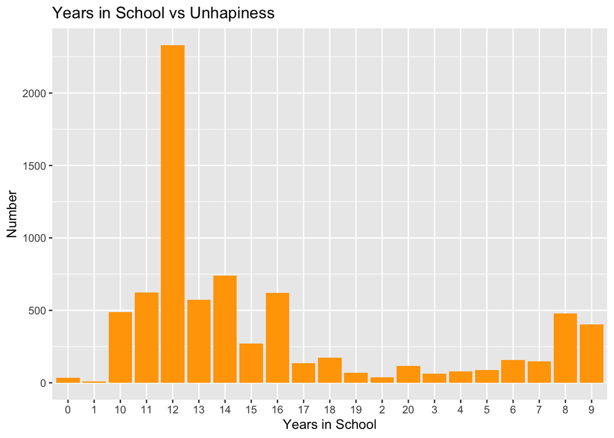

```r
ggplot(dfNotHappy, aes(x = school)) + geom_bar(fill="orange") + ggtitle("Years in School vs Unhapiness")+xlab("Years in School")+ylab("Number")
```

It is pretty much the same as hours worked, it seems that people that did higher education are happier than the people that didnt do it but it also looks like some people regretted doing their higher education.